# SNP clinality

Tue Dec 20 15:46:42 2016

# Data

We are only looking at scaffolds with at least 400 SNPs per scaffold, and SNPs with total depth between 150 and 500; this is a proportion 0.764187 of the SNPs. Overall, we've got a depth of about 288.7019229; on the longer scaffolds this is 297.8671038;

# Computation

We want to compute the correlation and covariance of each site with a vector, $v$ (say, PC1). If at a given site:

- $c(i) =$ major allele count in indiv $i$
- $n(i) =$ sample size, i.e. coverage of indiv $i$
- $p(i) =$ $c(i)/n(i)$
- $v(i) =$ vector of weights

then we need these things:

- $A = \sum_i p(i)$
- $B = \sum_i p(i) v(i)$
- $C = \sum_{i : p(i)>0} v(i)$
- $D = \sum_{i : p(i)>0} v(i)^2$
- $N = \#\{ i : n(i) > 0 \}$

Then, we estimate the covariance by
$$( B - A C / N ) / N$$
and the correlation by
$$( \text{covariance} ) / \sqrt{ ( ( A - A^2 / N ) / (N-1) ) ( ( D - C^2 / N ) / (N-1) ) }
= ( B N - A C ) (N-1) / N \sqrt{ ( A N - A^2 ) ( D N - C^2 ) }$$

The five columns of the pcXcounts files are $A$, $B$, $C$, $D$, and $N$, respectively.

Note that from these data we can also look for clinality in the **missing** data. Suppose that

- $z(i) = 1$ if the allele is missing in individual $i$ and $=0$ otherwise;
- $C = \sum_i v(i) z(i)$
- $N = \sum_i z(i)$
- $n_I =$ the number of individuals
- $\bar v = \sum_i v(i) / n_I$
- $\sigma^2_v = \sum_i (v(i)-\bar v)^2 / (n_I-1)$

and so the covariance of $z$ with $v$ is
$$( C - N \sum_i v(i) / n_I ) / n_I$$
and the correlation is
$$( \text{covariance} ) / \sqrt{ ( N / n_I )( 1 - N/n_I ) \sigma^2_v } .$$

# Summary stats

Here is the histogram of minor allele frequencies, with and without the filters above: (recall that these were already selected by angsd as likely polymorphic)

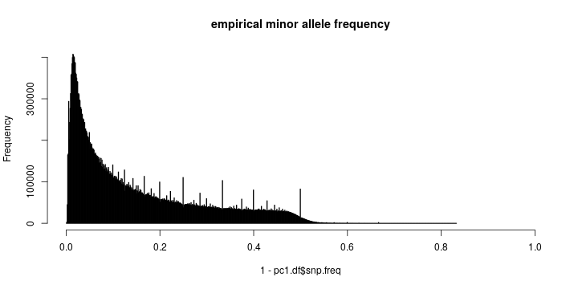

```r
hist(1-pc1.df$snp.freq,breaks=1000, xlim=c(0,1), main="empirical minor allele frequency")
```

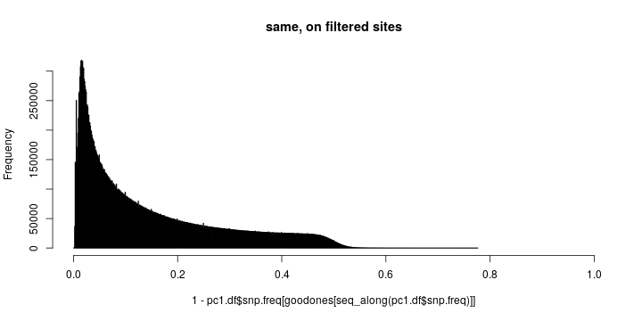

```r
hist(1-pc1.df$snp.freq[goodones[seq_along(pc1.df$snp.freq)]],breaks=1000, xlim=c(0,1), main="same, on filtered sites")
```

Some more summary statistics. We don't have the scaffold lengths handy, so we'll just use the maximal position of a SNP: Here is the density of segregating sites, mean divergence at segregating sites (calculated as $2p(1-p)$, where $p$ is the minor allele frequency), and mean divergence overall, on scaffolds of length at least 10Kb:

```r
dens.segsites <- scaf.counts/scaf.len
mean.segsites.pi <- tapply( pc1.df$snp.freq, pos$chr, function (x) { mean(2 * x * (1-x)) } )
mean.pi <- tapply( pc1.df$snp.freq, pos$chr, function (x) { sum(2 * x * (1-x)) } ) / scaf.len
usethese <- (scaf.len>10000)
scaf.summaries <- data.frame( "scaffold length"=scaf.len[usethese],
                  "seg. sites per bp"=as.vector(dens.segsites[usethese]),
                  "divergence at seg sites"=mean.segsites.pi[usethese],
                  "divergence"=mean.pi[usethese]
              )
cor(scaf.summaries)
```

```
##                         scaffold.length seg..sites.per.bp
## scaffold.length             1.000000000        -0.2365395
## seg..sites.per.bp          -0.236539489         1.0000000
## divergence.at.seg.sites    -0.009334975        -0.3076649
## divergence                 -0.272748654         0.9089350
##                         divergence.at.seg.sites divergence
## scaffold.length                    -0.009334975 -0.2727487
## seg..sites.per.bp                  -0.307664907  0.9089350
## divergence.at.seg.sites             1.000000000  0.0284470
## divergence                          0.028446997  1.0000000
```

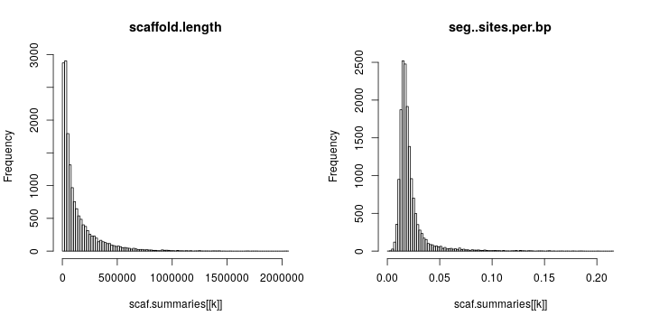

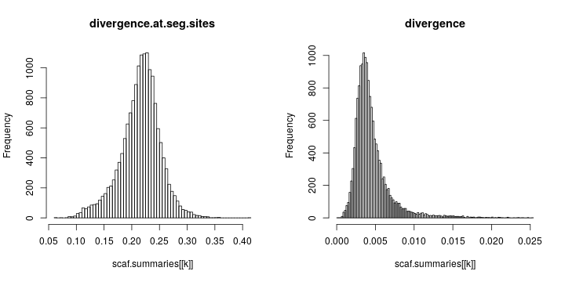

```r
layout(t(1:2))
for (k in 1:ncol(scaf.summaries)) {
    hist(scaf.summaries[[k]], main=names(scaf.summaries)[k], breaks=100)
}
```

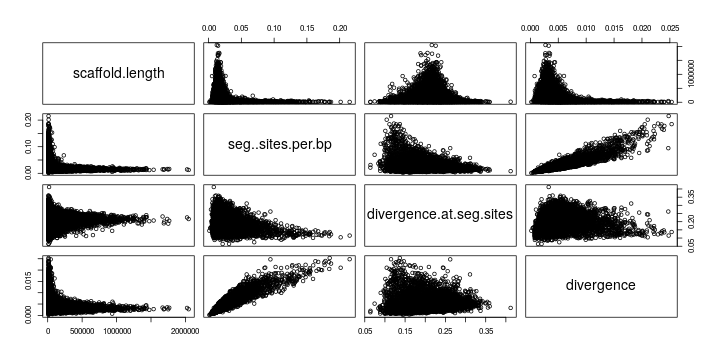

```r
pairs(scaf.summaries)
```

# Correlation coefficients

This plot shows the number of SNPs having at least a certain absolute correlation with PC1 that pass the coverage conditions above:

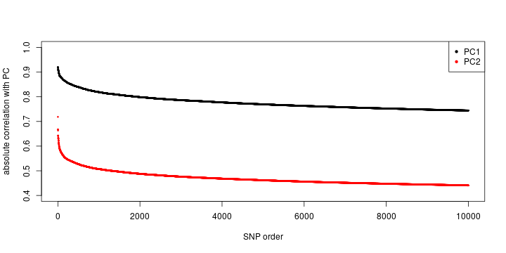

```r
filtered <- ( ( pos$totDepth >= mindepth ) & ( pos$totDepth <= maxdepth ) )
plot( head(sort(abs(pc1.df$snp.cor[filtered]),decr=TRUE),10000),
        ylab="absolute correlation with PC", ylim=c(0.4,1),
        xlab="SNP order", pch=20, cex=0.5 )
points( head(sort(abs(pc2.df$snp.cor[filtered]),decr=TRUE),10000),
        col='red', pch=20, cex=0.5 )
legend("topright",pch=20,col=c("black","red"),legend=c("PC1","PC2"))
```

And, here are the distributions of correlation coefficients with the PCs:

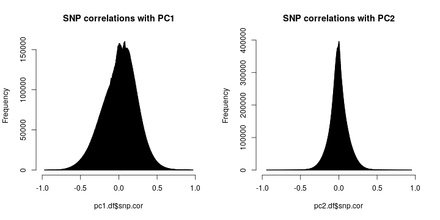

```r
layout(t(1:2))
hist(pc1.df$snp.cor,breaks=1000,xlim=c(-1,1), main="SNP correlations with PC1")
hist(pc2.df$snp.cor,breaks=1000,xlim=c(-1,1), main="SNP correlations with PC2")
```

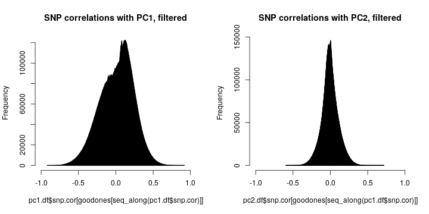

```r
hist(pc1.df$snp.cor[goodones[seq_along(pc1.df$snp.cor)]],breaks=1000,xlim=c(-1,1), main="SNP correlations with PC1, filtered")
hist(pc2.df$snp.cor[goodones[seq_along(pc1.df$snp.cor)]],breaks=1000,xlim=c(-1,1), main="SNP correlations with PC2, filtered")
```

Here is correlation against minor allele frequency:

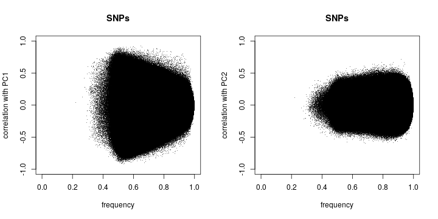

```r
layout(t(1:2))
plot( pc1.df$snp.freq[goodones], pc1.df$snp.cor[goodones], pch='.', col=adjustcolor("black",0.5), main="SNPs",
        xlim=c(0,1), ylim=c(-1,1), xlab="frequency", ylab="correlation with PC1" )
plot( pc2.df$snp.freq[goodones], pc2.df$snp.cor[goodones], pch='.', col=adjustcolor("black",0.5), main="SNPs",
        xlim=c(0,1), ylim=c(-1,1), xlab="frequency", ylab="correlation with PC2" )
```

And, frequencies of missingness, with the distribution expected if coverage is Poisson(1.2):

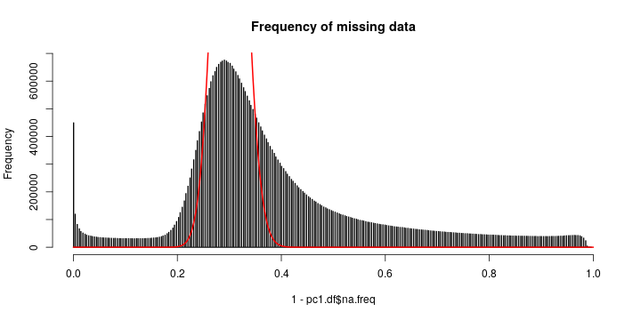

```r
xh <- hist(1-pc1.df$na.freq,breaks=1000, xlim=c(0,1), main="Frequency of missing data")
lines((0:nindivs)/nindivs, length(pc1.df$na.freq)*dbinom((0:nindivs),nindivs,exp(-1.2)),col='red',lwd=2)
```

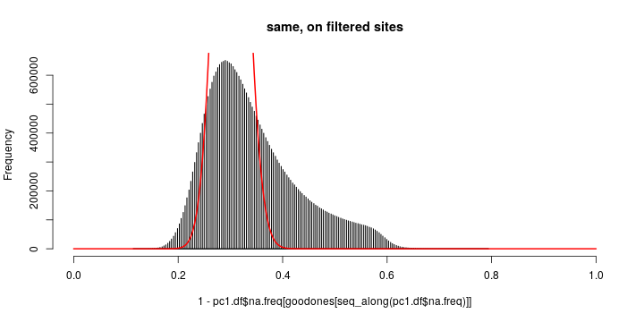

```r
xh <- hist(1-pc1.df$na.freq[goodones[seq_along(pc1.df$na.freq)]],breaks=1000, xlim=c(0,1), main="same, on filtered sites")
lines((0:nindivs)/nindivs, length(pc1.df$na.freq)*dbinom((0:nindivs),nindivs,exp(-1.2)),col='red',lwd=2)
```

and, distributions of correlation coefficients:

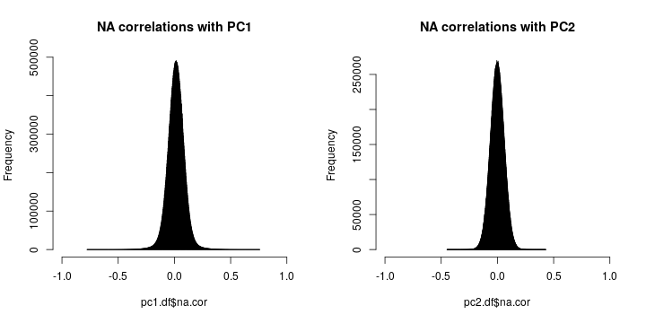

```r
layout(t(1:2))
hist(pc1.df$na.cor,breaks=1000,xlim=c(-1,1), main="NA correlations with PC1")
hist(pc2.df$na.cor,breaks=1000,xlim=c(-1,1), main="NA correlations with PC2")
```

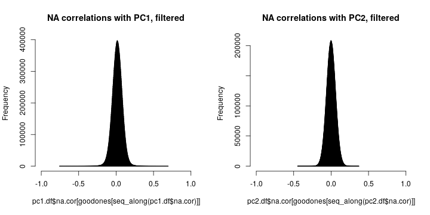

```r
hist(pc1.df$na.cor[goodones[seq_along(pc1.df$na.cor)]],breaks=1000,xlim=c(-1,1), main="NA correlations with PC1, filtered")
hist(pc2.df$na.cor[goodones[seq_along(pc2.df$na.cor)]],breaks=1000,xlim=c(-1,1), main="NA correlations with PC2, filtered")
```

and, correlation against minor allele frequency:

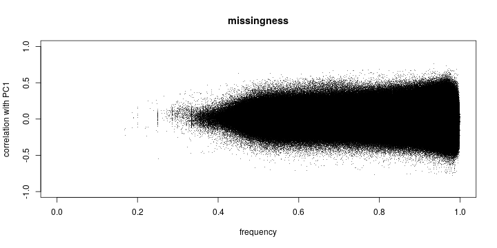

```r
plot( pc1.df$snp.freq, pc1.df$na.cor, pch='.', col=adjustcolor("black",0.5), main="missingness",
        xlim=c(0,1), ylim=c(-1,1), xlab="frequency", ylab="correlation with PC1" )
```

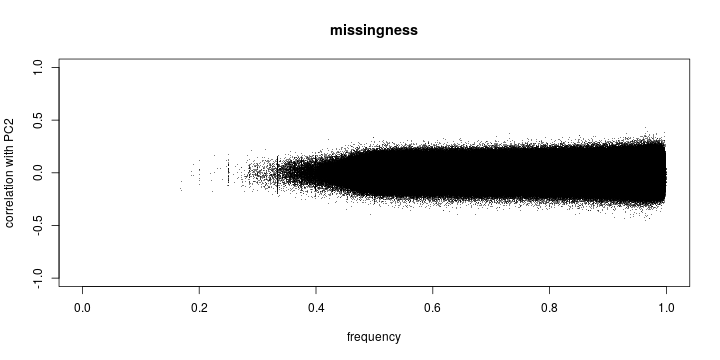

```r
plot( pc2.df$snp.freq, pc2.df$na.cor, pch='.', col=adjustcolor("black",0.5), main="missingness",
        xlim=c(0,1), ylim=c(-1,1), xlab="frequency", ylab="correlation with PC2" )
```

# "Along the genome"

Here is a plot of how the larger correlations fall out on the scaffolds:

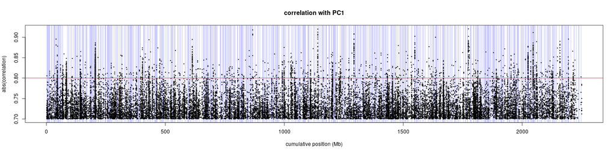

```r
zz <- ifelse(goodones & abs(pc1.df$snp.cor)>0.7, abs(pc1.df$snp.cor), NA)
scafplot( zz, ylab='abs(correlation)', main='correlation with PC1')
abline(h=0.8,col='red')
```

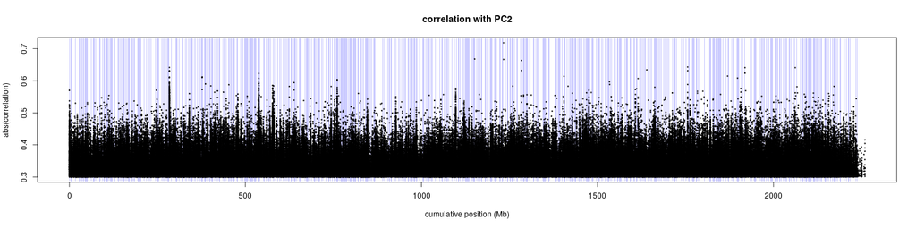

```r
# points( scaf.pos/1e6, tapply(zz,pos$chr,mean,na.rm=TRUE), col='orange', cex=0.25 )
# points( scaf.pos/1e6, tapply(ifelse(goodones,abs(pc1.df$snp.cor),NA),pos$chr,mean,na.rm=TRUE), col='red', pch=20, cex=0.25 )

zz <- ifelse(goodones & abs(pc2.df$snp.cor)>0.3, abs(pc2.df$snp.cor), NA)
scafplot( zz, ylab='abs(correlation)', main='correlation with PC2')
```

```r
# points( scaf.pos/1e6, tapply(zz,pos$chr,mean,na.rm=TRUE), col='orange', cex=0.25 )
# points( scaf.pos/1e6, tapply(ifelse(goodones,abs(pc2.df$snp.cor),NA),pos$chr,mean,na.rm=TRUE), col='red', pch=20, cex=0.25 )
```

Do outliers in correlation with the two PCs coincide? These scaffolds have at least one outlier in both senses: (note these cutoffs are above the 99.99% tail)

```r
mean(pc1.df$snp.cor[goodones]<0.75)
```

```
## [1] 0.9999324
```

```r
mean(pc2.df$snp.cor[goodones]<0.5)
```

```
## [1] 0.9999719
```

```r
levels(pos$chr)[which(pmin(tapply( pc1.df$snp.cor>0.75 & goodones, pos$chr, sum ), tapply( pc2.df$snp.cor>0.5 & goodones, pos$chr, sum ) )>0)]
```

```
##  [1] "scaffold_230"  "scaffold_695"  "scaffold_806"  "scaffold_893"
##  [5] "scaffold_1395" "scaffold_1423" "scaffold_1444" "scaffold_1536"
##  [9] "scaffold_1556" "scaffold_1706" "scaffold_1726" "scaffold_1727"
## [13] "scaffold_1816" "scaffold_1889" "scaffold_1917" "scaffold_1997"
## [17] "scaffold_2026" "scaffold_2052" "scaffold_2062" "scaffold_2116"
## [21] "scaffold_2628" "scaffold_2821" "scaffold_2832" "scaffold_2894"
## [25] "scaffold_2947" "scaffold_3029" "scaffold_3035" "scaffold_3089"
## [29] "scaffold_3242" "scaffold312"   "scaffold1483"  "scaffold1913"
## [33] "scaffold1931"  "scaffold2319"  "scaffold2752"  "scaffold7205"
## [37] "scaffold7244"  "scaffold7919"  "scaffold8001"  "scaffold8387"
## [41] "scaffold8757"  "scaffold9032"  "scaffold11389" "scaffold13374"
## [45] "scaffold15943" "scaffold16227" "scaffold24120" "scaffold24367"
## [49] "scaffold30731"
```

# By scaffold

The mitochondrial haplotype has correlation above 0.8 with PC1. There are 526 SNPs on 235 scaffolds that pass this threshold.

First, let's look at the top ten longest scaffolds. **Above zero** are *absolute* correlations with **PC1**, and below are with **PC2**:

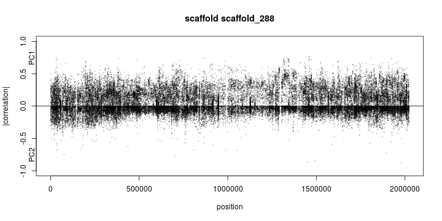

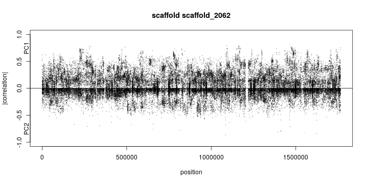

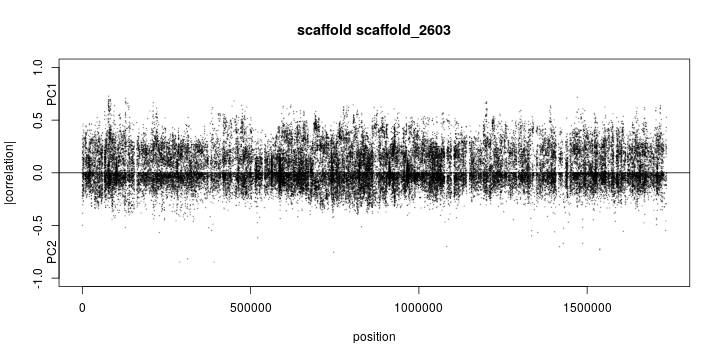

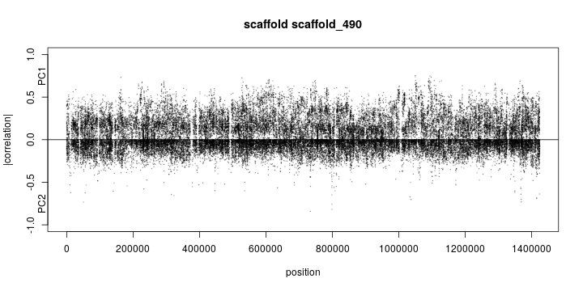

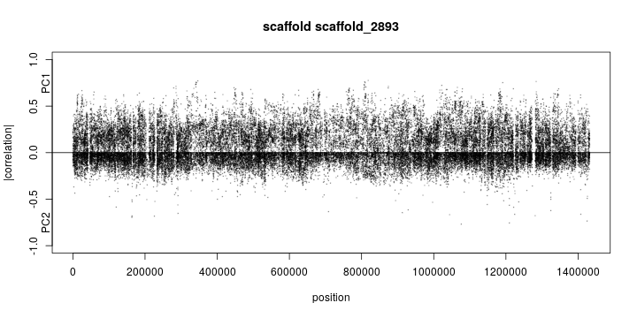

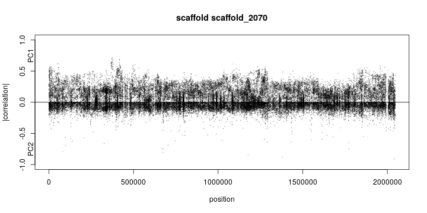

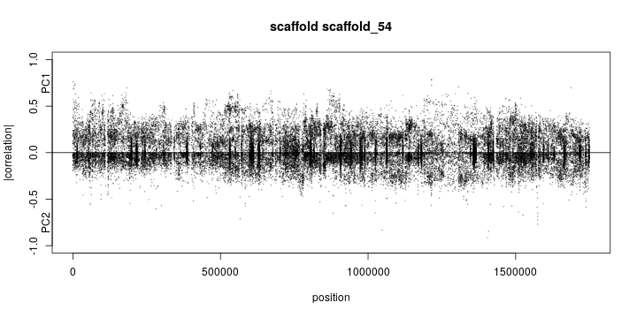

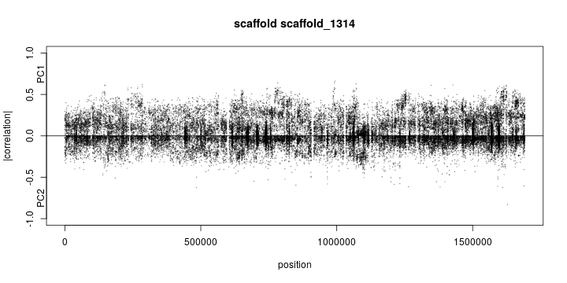

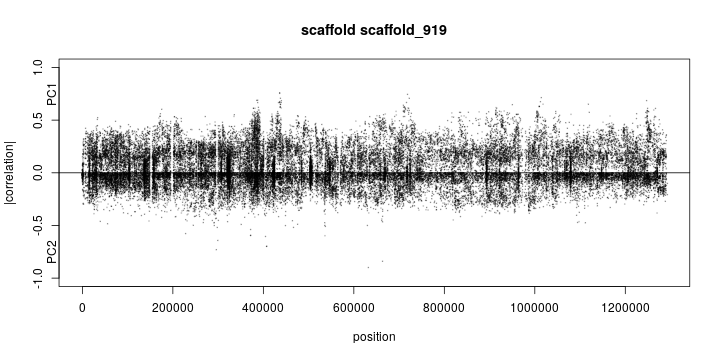

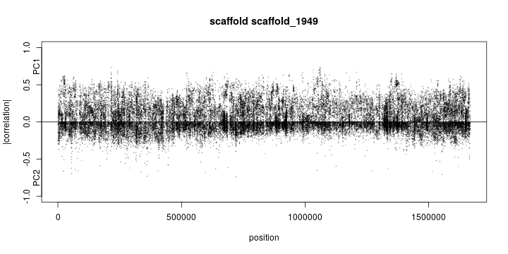

```r
superlong <- names(sort(scaf.counts,decreasing=TRUE)[1:10])
for (scaf in superlong) {
    plot( pos$pos[pos$chr==scaf & goodones], abs(pc1.df$snp.cor[pos$chr==scaf & goodones]),
            xlab='position', ylab='|correlation|', main=paste('scaffold',scaf),
            cex=0.25, pch=20, col=adjustcolor('black',0.25), ylim=c(-1,1) )
    mtext(c("PC1","PC2"),side=2,at=c(1,-1)*.75)
    points( pos$pos[pos$chr==scaf], -abs(pc2.df$snp.cor[pos$chr==scaf]),
            cex=0.25, pch=20, col=adjustcolor('black',0.25), ylim=c(-1,1) )
    abline(h=0)
}
```

OK, let's see how correlations partition by scaffold.

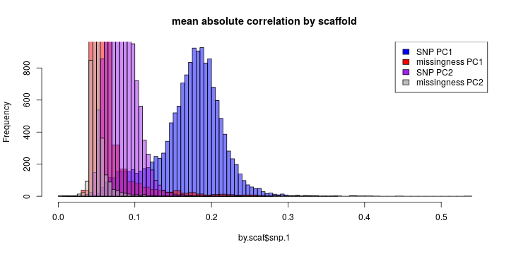

```r
by.scaf <- data.frame(
        snp.1 = tapply( abs(pc1.df$snp.cor[goodones]), pos$chr[goodones], mean ),
        na.1 = tapply( abs(pc1.df$na.cor[goodones]), pos$chr[goodones], mean ),
        snp.2 = tapply( abs(pc2.df$snp.cor[goodones]), pos$chr[goodones], mean ),
        na.2 = tapply( abs(pc2.df$na.cor[goodones]), pos$chr[goodones], mean )
    )
hist( by.scaf$snp.1, xlim=range(0,by.scaf,finite=TRUE), breaks=50,
        col=adjustcolor("blue",0.5), freq=TRUE, main='mean absolute correlation by scaffold' )
hist( by.scaf$na.1, breaks=50, add=TRUE, freq=TRUE, col=adjustcolor("red",0.5) )
hist( by.scaf$snp.2, breaks=50, add=TRUE, freq=TRUE, col=adjustcolor("purple",0.5) )
hist( by.scaf$na.2, breaks=50, add=TRUE, freq=TRUE, col=adjustcolor("grey",0.5) )
legend("topright", fill=c('blue','red','purple','grey'), legend=outer(c('SNP', 'missingness'),c("PC1","PC2"),paste))
```

## Is there an enrichment of high-correlation SNPs by scaffold?

Now we'll look at numbers of SNPs with correlations with PC1 above certain thresholds, by scaffold:

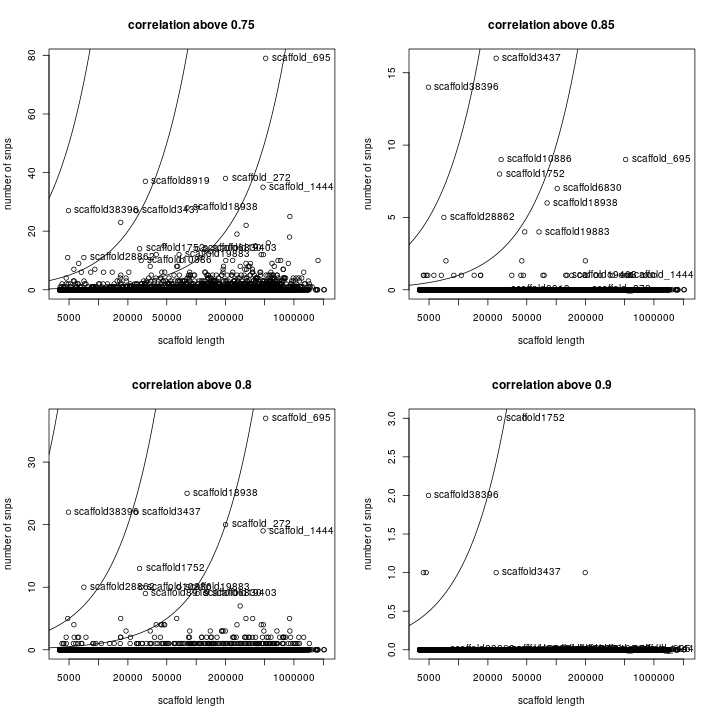

```r
cor.breaks <- seq(.75,.9,by=.05)
num.highcors <- sapply( cor.breaks, function (cb) {
            tapply( (pc1.df$snp.cor >= cb) & (pos$totDepth > mindepth) & (pos$totDepth < maxdepth), pos$chr, sum, na.rm=TRUE )
        } )
dens.highcors <- sweep(num.highcors,1,scaf.len,"/")
outliers <- rownames(num.highcors)[num.highcors[,2]>8]
outliers.ind <- match(outliers,levels(pos$chr))
layout(matrix(1:4,nrow=2))
for (k in seq_along(cor.breaks)) {
    plot( scaf.len[scaf.len>4e3], num.highcors[scaf.len>4e3,k], log='x',
         xlab='scaffold length', ylab='number of snps', main=paste('correlation above', cor.breaks[k]) )
    for (sl in c(.01,.001,.0001)) { abline(0,sl,untf=TRUE)}
    text( scaf.len[outliers.ind], num.highcors[outliers.ind,k], labels=outliers, pos=4 )
}
```